# RNotebook: Resolución Prueba DGA

**Resumen:** El presente código fue desarrollado por **Elias Preza** para optar a la plaza de Senior Data Scientist de la Dirección General de Aduana **DGA**, en su contenido se resuelve sintaxis para el ejercicio de la **parte: 1 de Manejo de Datos** y la para la **parte 2: la Construcción de un Modelo de Machine Learning**.

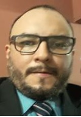

[Link hacia perfil de Linkedin](https://www.linkedin.com/in/elias-preza-316531b3/)

# Preparación de Librerias

```r
library(tidyverse)
library(readr)
library(sjmisc)
```

# Preparación de bases de datos

## Data Set: BX_Books

```r
BX_Books<- read_delim("BX-Books.csv", ";",
                       escape_double = FALSE, trim_ws = TRUE)
dplyr::glimpse(BX_Books)
```

```
Rows: 271,379
Columns: 8
$ ISBN                  <chr> "0195153448", "0002005018", "0060973129", "0374157065", "0393045218", "0399135782", ...
$ `Book-Title`          <chr> "Classical Mythology", "Clara Callan", "Decision in Normandy", "Flu: The Story of th...
$ `Book-Author`         <chr> "Mark P. O. Morford", "Richard Bruce Wright", "Carlo D'Este", "Gina Bari Kolata", "E...
$ `Year-Of-Publication` <dbl> 2002, 2001, 1991, 1999, 1999, 1991, 2000, 1993, 1996, 2002, 1988, 2000, 2004, 1999, ...
$ Publisher             <chr> "Oxford University Press", "HarperFlamingo Canada", "HarperPerennial", "Farrar Strau...
$ `Image-URL-S`         <chr> "http://images.amazon.com/images/P/0195153448.01.THUMBZZZ.jpg", "http://images.amazo...
$ `Image-URL-M`         <chr> "http://images.amazon.com/images/P/0195153448.01.MZZZZZZZ.jpg", "http://images.amazo...
$ `Image-URL-L`         <chr> "http://images.amazon.com/images/P/0195153448.01.LZZZZZZZ.jpg", "http://images.amazo...
```

```r
head(BX_Books,5)
```

| ISBN | Book-Title | Book-Author | Year-Of-Publication | Publisher | Image-URL-S | Image-URL-M | Image-URL-L |
| --- | --- | --- | --- | --- | --- | --- | --- |
| 0195153448 | Classical Mythology | Mark P. O. Morford | 2002 | Oxford University Press | http://images.amazon.com/images/P/0195153448.01.THUMBZZZ.jpg | http://images.amazon.com/images/P/0195153448.01.MZZZZZZZ.jpg | http://images.amazon.com/images/P/0195153448.01.LZZZZZZZ.jpg |
| 0002005018 | Clara Callan | Richard Bruce Wright | 2001 | HarperFlamingo Canada | http://images.amazon.com/images/P/0002005018.01.THUMBZZZ.jpg | http://images.amazon.com/images/P/0002005018.01.MZZZZZZZ.jpg | http://images.amazon.com/images/P/0002005018.01.LZZZZZZZ.jpg |
| 0060973129 | Decision in Normandy | Carlo D'Este | 1991 | HarperPerennial | http://images.amazon.com/images/P/0060973129.01.THUMBZZZ.jpg | http://images.amazon.com/images/P/0060973129.01.MZZZZZZZ.jpg | http://images.amazon.com/images/P/0060973129.01.LZZZZZZZ.jpg |
| 0374157065 | Flu: The Story of the Great Influenza Pandemic of 1918 and the Search for the Virus That Caused It | Gina Bari Kolata | 1999 | Farrar Straus Giroux | http://images.amazon.com/images/P/0374157065.01.THUMBZZZ.jpg | http://images.amazon.com/images/P/0374157065.01.MZZZZZZZ.jpg | http://images.amazon.com/images/P/0374157065.01.LZZZZZZZ.jpg |
| 0393045218 | The Mummies of Urumchi | E. J. W. Barber | 1999 | W. W. Norton &amp Company | http://images.amazon.com/images/P/0393045218.01.THUMBZZZ.jpg | http://images.amazon.com/images/P/0393045218.01.MZZZZZZZ.jpg | http://images.amazon.com/images/P/0393045218.01.LZZZZZZZ.jpg |

```r
NA
```

## Data Set: BX_Book_Ratings

```r
BX_Book_Ratings<-read_delim("BX-Book-Ratings.csv", ";",
                            escape_double = FALSE, trim_ws = TRUE)

dplyr::glimpse(BX_Book_Ratings)
```

```
Rows: 1,149,780
Columns: 3
$ `User-ID`     <dbl> 276725, 276726, 276727, 276729, 276729, 276733, 276736, 276737, 276744, 276745, 276746, 2767...
$ ISBN          <chr> "034545104X", "0155061224", "0446520802", "052165615X", "0521795028", "2080674722", "3257224...
$ `Book-Rating` <dbl> 0, 5, 0, 3, 6, 0, 8, 6, 7, 10, 0, 0, 0, 0, 0, 0, 9, 0, 0, 9, 8, 7, 0, 7, 6, 0, 0, 8, 8, 5, 1...
```

```r
head(BX_Book_Ratings,5)
```

| User-ID | ISBN | Book-Rating |
| --- | --- | --- |
| 276725 | 034545104X | 0 |
| 276726 | 0155061224 | 5 |
| 276727 | 0446520802 | 0 |
| 276729 | 052165615X | 3 |
| 276729 | 0521795028 | 6 |

## Data Set: BX_Users

```r
BX_Users<-read_delim("BX-Users.csv", ";",
                            escape_double = FALSE, trim_ws = TRUE)

dplyr::glimpse(BX_Users)
```

```
Rows: 278,858
Columns: 3
$ `User-ID` <dbl> 1, 2, 3, 4, 5, 6, 7, 8, 9, 10, 11, 12, 13, 14, 15, 16, 17, 18, 19, 20, 21, 22, 23, 24, 25, 26, 2...
$ Location  <chr> "nyc, new york, usa", "stockton, california, usa", "moscow, yukon territory, russia", "porto, v....
$ Age       <chr> "NULL", "18", "NULL", "17", "NULL", "61", "NULL", "NULL", "NULL", "26", "14", "NULL", "26", "NUL...
```

```r
head(BX_Users,5)
```

| User-ID | Location | Age |
| --- | --- | --- |
| 1 | nyc, new york, usa | NULL |
| 2 | stockton, california, usa | 18 |
| 3 | moscow, yukon territory, russia | NULL |
| 4 | porto, v.n.gaia, portugal | 17 |
| 5 | farnborough, hants, united kingdom | NULL |

# PARTE 1: Manejo de Datos

Como sabrás, en el trabajo de un científico de datos es necesario saber manejar datos de fuentes diversas para crear datasets para el entrenamiento de modelos de aprendizaje de máquina. En esta parte de la prueba descargaras el dataset: Book-Crossing Dataset. Un dataset para la creación de un sistema de recomendación de libros recopilado por Cai-Nicolas Ziegler del Instituto para la Informática de la Universidad de Freiburg. Podés descargar el dataset como un Zip aquí.

Puedes usar R, Python o cualquier lenguaje de programación de tu preferencia para responder las siguientes preguntas, te pedimos que nos adjuntes el código que usaste para resolverlas.

## Literal a

Te pedimos que agregues los archivos en la carpeta descargada para formar un dataset que pueda ser usado para entrenar un modelo de agrupación como KNN o un sistema de recomendaciones.

**<<En este agregado se fusionaron los tres Data-Set para contar con todas las variables claves que pueden servir para un análisis más profundo y aplicar un modelo de clasificación o de recomendación, porque puede perfilarse al usuario desde su edad, lugar de residencia, cantidad o frecuencia de lectura, su preferencia de libros, autores e editoriales; con transformaciones en variables cualitativas ya estandarizadas a númericas se podría factiblemente correr modelos>>.**

```r
base1<-left_join(BX_Book_Ratings,BX_Books,by=c("ISBN"="ISBN"))

agregado<-left_join(base1,BX_Users,by=c("User-ID"="User-ID"))

dplyr::glimpse(agregado)
```

```
Rows: 1,149,792
Columns: 12
$ `User-ID`             <dbl> 276725, 276726, 276727, 276729, 276729, 276733, 276736, 276737, 276744, 276745, 2767...
$ ISBN                  <chr> "034545104X", "0155061224", "0446520802", "052165615X", "0521795028", "2080674722", ...
$ `Book-Rating`         <dbl> 0, 5, 0, 3, 6, 0, 8, 6, 7, 10, 0, 0, 0, 0, 0, 0, 9, 0, 0, 9, 8, 7, 0, 7, 6, 0, 0, 8,...
$ `Book-Title`          <chr> "Flesh Tones: A Novel", "Rites of Passage", "The Notebook", "Help!: Level 1", "The A...
$ `Book-Author`         <chr> "M. J. Rose", "Judith Rae", "Nicholas Sparks", "Philip Prowse", "Sue Leather", "Mich...
$ `Year-Of-Publication` <dbl> 2002, 2001, 1996, 1999, 2001, 1998, NA, NA, 2001, NA, 1996, 2002, 1994, 1995, 2002, ...
$ Publisher             <chr> "Ballantine Books", "Heinle", "Warner Books", "Cambridge University Press", "Cambrid...
$ `Image-URL-S`         <chr> "http://images.amazon.com/images/P/034545104X.01.THUMBZZZ.jpg", "http://images.amazo...
$ `Image-URL-M`         <chr> "http://images.amazon.com/images/P/034545104X.01.MZZZZZZZ.jpg", "http://images.amazo...
$ `Image-URL-L`         <chr> "http://images.amazon.com/images/P/034545104X.01.LZZZZZZZ.jpg", "http://images.amazo...
$ Location              <chr> "tyler, texas, usa", "seattle, washington, usa", "h, new south wales, australia", "r...
$ Age                   <chr> "NULL", "NULL", "16", "16", "16", "37", "NULL", "14", "NULL", "27", "NULL", "NULL", ...
```

```r
head(agregado,10)
```

| User-ID | ISBN | Book-Rating | Book-Title | Book-Author | Year-Of-Publication | Publisher | Image-URL-S | Image-URL-M | Image-URL-L | Location | Age |
| --- | --- | --- | --- | --- | --- | --- | --- | --- | --- | --- | --- |
| 276725 | 034545104X | 0 | Flesh Tones: A Novel | M. J. Rose | 2002 | Ballantine Books | http://images.amazon.com/images/P/034545104X.01.THUMBZZZ.jpg | http://images.amazon.com/images/P/034545104X.01.MZZZZZZZ.jpg | http://images.amazon.com/images/P/034545104X.01.LZZZZZZZ.jpg | tyler, texas, usa | NULL |
| 276726 | 0155061224 | 5 | Rites of Passage | Judith Rae | 2001 | Heinle | http://images.amazon.com/images/P/0155061224.01.THUMBZZZ.jpg | http://images.amazon.com/images/P/0155061224.01.MZZZZZZZ.jpg | http://images.amazon.com/images/P/0155061224.01.LZZZZZZZ.jpg | seattle, washington, usa | NULL |
| 276727 | 0446520802 | 0 | The Notebook | Nicholas Sparks | 1996 | Warner Books | http://images.amazon.com/images/P/0446520802.01.THUMBZZZ.jpg | http://images.amazon.com/images/P/0446520802.01.MZZZZZZZ.jpg | http://images.amazon.com/images/P/0446520802.01.LZZZZZZZ.jpg | h, new south wales, australia | 16 |
| 276729 | 052165615X | 3 | Help!: Level 1 | Philip Prowse | 1999 | Cambridge University Press | http://images.amazon.com/images/P/052165615X.01.THUMBZZZ.jpg | http://images.amazon.com/images/P/052165615X.01.MZZZZZZZ.jpg | http://images.amazon.com/images/P/052165615X.01.LZZZZZZZ.jpg | rijeka, n/a, croatia | 16 |
| 276729 | 0521795028 | 6 | The Amsterdam Connection : Level 4 (Cambridge English Readers) | Sue Leather | 2001 | Cambridge University Press | http://images.amazon.com/images/P/0521795028.01.THUMBZZZ.jpg | http://images.amazon.com/images/P/0521795028.01.MZZZZZZZ.jpg | http://images.amazon.com/images/P/0521795028.01.LZZZZZZZ.jpg | rijeka, n/a, croatia | 16 |
| 276733 | 2080674722 | 0 | Les Particules Elementaires | Michel Houellebecq | 1998 | Flammarion | http://images.amazon.com/images/P/2080674722.01.THUMBZZZ.jpg | http://images.amazon.com/images/P/2080674722.01.MZZZZZZZ.jpg | http://images.amazon.com/images/P/2080674722.01.LZZZZZZZ.jpg | paris, n/a, france | 37 |
| 276736 | 3257224281 | 8 | NA | NA | NA | NA | NA | NA | NA | salzburg, salzburg, austria | NULL |
| 276737 | 0600570967 | 6 | NA | NA | NA | NA | NA | NA | NA | sydney, new south wales, australia | 14 |
| 276744 | 038550120X | 7 | A Painted House | JOHN GRISHAM | 2001 | Doubleday | http://images.amazon.com/images/P/038550120X.01.THUMBZZZ.jpg | http://images.amazon.com/images/P/038550120X.01.MZZZZZZZ.jpg | http://images.amazon.com/images/P/038550120X.01.LZZZZZZZ.jpg | torrance, california, usa | NULL |
| 276745 | 342310538 | 10 | NA | NA | NA | NA | NA | NA | NA | berlin, berlin, germany | 27 |

## Literal b

Ahora notaras que la ubicación del usuario está dada por ciudad, estado o región y país. Crea columnas separadas que contengan el país, ciudad y región de cada usuario.

**<< Se preparo una desconcatenación de la columna de Location posteriormente se procedió a extraer y renombrar unicamente a las variables de interes >>.**

```r
ubicacion <- within(data=BX_Users, Location<-data.frame
                     (do.call('rbind',strsplit(as.character(Location),",",fixed=TRUE))))
```

```
number of columns of result is not a multiple of vector length (arg 19)
```

```r
ubicacion<-ubicacion%>%
    dplyr::mutate(ciudad=ubicacion$Location$X1,región=ubicacion$Location$X2,país=ubicacion$Location$X3,edad=ubicacion$Age) %>%
    dplyr::select(`User-ID`,país,región,ciudad,edad)

head(ubicacion,5)
```

| User-ID | país | región | ciudad | edad |
| --- | --- | --- | --- | --- |
| 1 | usa | new york | nyc | NULL |
| 2 | usa | california | stockton | 18 |
| 3 | russia | yukon territory | moscow | NULL |
| 4 | portugal | v.n.gaia | porto | 17 |
| 5 | united kingdom | hants | farnborough | NULL |

## Literal c

¿Cuáles son los libros con más raitings?

**<< Se desarrollo una agregación por ISBN para obtener únicos ISBN y obtener las sumas de los raitings por libro, luego se fusiono con la de libros para pegar los detalles como nombre, autor editorial, etc >>.**

```r
frq(agregado$`Book-Rating`) #--Solo para verificar la frecuencia del raiting
```

```
x <numeric>
# total N=1149792  valid N=1149792  mean=2.87  sd=3.85

Value |      N | Raw % | Valid % | Cum. %
-----------------------------------------
    0 | 716117 | 62.28 |   62.28 |  62.28
    1 |   1770 |  0.15 |    0.15 |  62.44
    2 |   2759 |  0.24 |    0.24 |  62.68
    3 |   5996 |  0.52 |    0.52 |  63.20
    4 |   8904 |  0.77 |    0.77 |  63.97
    5 |  50974 |  4.43 |    4.43 |  68.41
    6 |  36925 |  3.21 |    3.21 |  71.62
    7 |  76458 |  6.65 |    6.65 |  78.27
    8 | 103737 |  9.02 |    9.02 |  87.29
    9 |  67542 |  5.87 |    5.87 |  93.16
   10 |  78610 |  6.84 |    6.84 | 100.00
 <NA> |      0 |  0.00 |    <NA> |   <NA>
```

```r
#---agregndo los raiting de la base BX_Book_Ratings para fusionarla con BX_Books

dplyr::glimpse(BX_Book_Ratings)
```

```
Rows: 1,149,780
Columns: 3
$ `User-ID`     <dbl> 276725, 276726, 276727, 276729, 276729, 276733, 276736, 276737, 276744, 276745, 276746, 2767...
$ ISBN          <chr> "034545104X", "0155061224", "0446520802", "052165615X", "0521795028", "2080674722", "3257224...
$ `Book-Rating` <dbl> 0, 5, 0, 3, 6, 0, 8, 6, 7, 10, 0, 0, 0, 0, 0, 0, 9, 0, 0, 9, 8, 7, 0, 7, 6, 0, 0, 8, 8, 5, 1...
```

```r
AgregadoRainting<-BX_Book_Ratings %>%
  dplyr::select(ISBN,`Book-Rating`)%>%
  dplyr::group_by(ISBN)%>%
  dplyr::summarise(RaitingsLibro=sum(`Book-Rating`))


#----fusionando la base para conocer el nombre de los libros con mayor raitings

base2<-left_join(AgregadoRainting,BX_Books,by=c("ISBN"="ISBN"))

dplyr::glimpse(base2)
```

```
Rows: 340,554
Columns: 9
$ ISBN                  <chr> "'9607092856'", "'9607092910'", "\"\\\"0094749809\"", "\"\\\"0210000010\"", "\"\\\"0...
$ RaitingsLibro         <dbl> 0, 10, 7, 8, 9, 20, 8, 7, 0, 7, 10, 5, 10, 0, 5, 0, 8, 0, 8, 7, 0, 0, 0, 6, 9, 7, 5,...
$ `Book-Title`          <chr> NA, NA, NA, NA, NA, NA, NA, NA, NA, NA, NA, NA, NA, NA, NA, NA, NA, NA, NA, NA, NA, ...
$ `Book-Author`         <chr> NA, NA, NA, NA, NA, NA, NA, NA, NA, NA, NA, NA, NA, NA, NA, NA, NA, NA, NA, NA, NA, ...
$ `Year-Of-Publication` <dbl> NA, NA, NA, NA, NA, NA, NA, NA, NA, NA, NA, NA, NA, NA, NA, NA, NA, NA, NA, NA, NA, ...
$ Publisher             <chr> NA, NA, NA, NA, NA, NA, NA, NA, NA, NA, NA, NA, NA, NA, NA, NA, NA, NA, NA, NA, NA, ...
$ `Image-URL-S`         <chr> NA, NA, NA, NA, NA, NA, NA, NA, NA, NA, NA, NA, NA, NA, NA, NA, NA, NA, NA, NA, NA, ...
$ `Image-URL-M`         <chr> NA, NA, NA, NA, NA, NA, NA, NA, NA, NA, NA, NA, NA, NA, NA, NA, NA, NA, NA, NA, NA, ...
$ `Image-URL-L`         <chr> NA, NA, NA, NA, NA, NA, NA, NA, NA, NA, NA, NA, NA, NA, NA, NA, NA, NA, NA, NA, NA, ...
```

```r
librosMasRaitings<-base2 %>%
  dplyr::arrange(desc(RaitingsLibro))

head(librosMasRaitings,10)
```

| ISBN | RaitingsLibro | Book-Title | Book-Author | Year-Of-Publication | Publisher | Image-URL-S | Image-URL-M | Image-URL-L |
| --- | --- | --- | --- | --- | --- | --- | --- | --- |
| 0316666343 | 5787 | The Lovely Bones: A Novel | Alice Sebold | 2002 | Little, Brown | http://images.amazon.com/images/P/0316666343.01.THUMBZZZ.jpg | http://images.amazon.com/images/P/0316666343.01.MZZZZZZZ.jpg | http://images.amazon.com/images/P/0316666343.01.LZZZZZZZ.jpg |
| 0385504209 | 4108 | The Da Vinci Code | Dan Brown | 2003 | Doubleday | http://images.amazon.com/images/P/0385504209.01.THUMBZZZ.jpg | http://images.amazon.com/images/P/0385504209.01.MZZZZZZZ.jpg | http://images.amazon.com/images/P/0385504209.01.LZZZZZZZ.jpg |
| 0312195516 | 3134 | The Red Tent (Bestselling Backlist) | Anita Diamant | 1998 | Picador USA | http://images.amazon.com/images/P/0312195516.01.THUMBZZZ.jpg | http://images.amazon.com/images/P/0312195516.01.MZZZZZZZ.jpg | http://images.amazon.com/images/P/0312195516.01.LZZZZZZZ.jpg |
| 0679781587 | 2800 | NA | NA | NA | NA | NA | NA | NA |
| 059035342X | 2798 | Harry Potter and the Sorcerer's Stone (Harry Potter (Paperback)) | J. K. Rowling | 1999 | Arthur A. Levine Books | http://images.amazon.com/images/P/059035342X.01.THUMBZZZ.jpg | http://images.amazon.com/images/P/059035342X.01.MZZZZZZZ.jpg | http://images.amazon.com/images/P/059035342X.01.LZZZZZZZ.jpg |
| 0142001740 | 2595 | The Secret Life of Bees | Sue Monk Kidd | 2003 | Penguin Books | http://images.amazon.com/images/P/0142001740.01.THUMBZZZ.jpg | http://images.amazon.com/images/P/0142001740.01.MZZZZZZZ.jpg | http://images.amazon.com/images/P/0142001740.01.LZZZZZZZ.jpg |
| 0971880107 | 2551 | Wild Animus | Rich Shapero | 2004 | Too Far | http://images.amazon.com/images/P/0971880107.01.THUMBZZZ.jpg | http://images.amazon.com/images/P/0971880107.01.MZZZZZZZ.jpg | http://images.amazon.com/images/P/0971880107.01.LZZZZZZZ.jpg |
| 0060928336 | 2524 | Divine Secrets of the Ya-Ya Sisterhood: A Novel | Rebecca Wells | 1997 | Perennial | http://images.amazon.com/images/P/0060928336.01.THUMBZZZ.jpg | http://images.amazon.com/images/P/0060928336.01.MZZZZZZZ.jpg | http://images.amazon.com/images/P/0060928336.01.LZZZZZZZ.jpg |
| 0446672211 | 2402 | Where the Heart Is (Oprah's Book Club (Paperback)) | Billie Letts | 1998 | Warner Books | http://images.amazon.com/images/P/0446672211.01.THUMBZZZ.jpg | http://images.amazon.com/images/P/0446672211.01.MZZZZZZZ.jpg | http://images.amazon.com/images/P/0446672211.01.LZZZZZZZ.jpg |
| 0452282152 | 2219 | Girl with a Pearl Earring | Tracy Chevalier | 2001 | Plume Books | http://images.amazon.com/images/P/0452282152.01.THUMBZZZ.jpg | http://images.amazon.com/images/P/0452282152.01.MZZZZZZZ.jpg | http://images.amazon.com/images/P/0452282152.01.LZZZZZZZ.jpg |

## Literal d

¿Cuál es el top 10 de libros con mejores ratings?

**<< Se retoma la base anterior de los raitings pero se ejecutaron los filtros con los mayores raitings, dejando los 10 primeros libros, se eliminaron los NA para la limpieza del top 10 >>.**

```r
dplyr::glimpse(librosMasRaitings)
```

```
Rows: 340,554
Columns: 9
$ ISBN                  <chr> "0316666343", "0385504209", "0312195516", "0679781587", "059035342X", "0142001740", ...
$ RaitingsLibro         <dbl> 5787, 4108, 3134, 2800, 2798, 2595, 2551, 2524, 2402, 2219, 2179, 2062, 2041, 1999, ...
$ `Book-Title`          <chr> "The Lovely Bones: A Novel", "The Da Vinci Code", "The Red Tent (Bestselling Backlis...
$ `Book-Author`         <chr> "Alice Sebold", "Dan Brown", "Anita Diamant", NA, "J. K. Rowling", "Sue Monk Kidd", ...
$ `Year-Of-Publication` <dbl> 2002, 2003, 1998, NA, 1999, 2003, 2004, 1997, 1998, 2001, 2001, 2001, 1999, 1995, 20...
$ Publisher             <chr> "Little, Brown", "Doubleday", "Picador USA", NA, "Arthur A. Levine Books", "Penguin ...
$ `Image-URL-S`         <chr> "http://images.amazon.com/images/P/0316666343.01.THUMBZZZ.jpg", "http://images.amazo...
$ `Image-URL-M`         <chr> "http://images.amazon.com/images/P/0316666343.01.MZZZZZZZ.jpg", "http://images.amazo...
$ `Image-URL-L`         <chr> "http://images.amazon.com/images/P/0316666343.01.LZZZZZZZ.jpg", "http://images.amazo...
```

```r
librosMasRaitingsNoNA<-na.omit(librosMasRaitings)#---se omite los NA para mayor limpieza

librosTop10Raitings<-librosMasRaitingsNoNA%>%
  dplyr::select(`Book-Title`,`Book-Author`,Publisher,RaitingsLibro)%>%
  dplyr::arrange(desc(RaitingsLibro))%>%
  dplyr::filter(RaitingsLibro>2062)

dplyr::glimpse(librosTop10Raitings)
```

```
Rows: 10
Columns: 4
$ `Book-Title`  <chr> "The Lovely Bones: A Novel", "The Da Vinci Code", "The Red Tent (Bestselling Backlist)", "Ha...
$ `Book-Author` <chr> "Alice Sebold", "Dan Brown", "Anita Diamant", "J. K. Rowling", "Sue Monk Kidd", "Rich Shaper...
$ Publisher     <chr> "Little, Brown", "Doubleday", "Picador USA", "Arthur A. Levine Books", "Penguin Books", "Too...
$ RaitingsLibro <dbl> 5787, 4108, 3134, 2798, 2595, 2551, 2524, 2402, 2219, 2179
```

```r
librosTop10Raitings<-librosTop10Raitings %>%
  dplyr::rename(Libro=`Book-Title`,Autor=`Book-Author`,Editorial=Publisher,Raiting=RaitingsLibro)

librosTop10Raitings
```

| Libro | Autor | Editorial | Raiting |
| --- | --- | --- | --- |
| The Lovely Bones: A Novel | Alice Sebold | Little, Brown | 5787 |
| The Da Vinci Code | Dan Brown | Doubleday | 4108 |
| The Red Tent (Bestselling Backlist) | Anita Diamant | Picador USA | 3134 |
| Harry Potter and the Sorcerer's Stone (Harry Potter (Paperback)) | J. K. Rowling | Arthur A. Levine Books | 2798 |
| The Secret Life of Bees | Sue Monk Kidd | Penguin Books | 2595 |
| Wild Animus | Rich Shapero | Too Far | 2551 |
| Divine Secrets of the Ya-Ya Sisterhood: A Novel | Rebecca Wells | Perennial | 2524 |
| Where the Heart Is (Oprah's Book Club (Paperback)) | Billie Letts | Warner Books | 2402 |
| Girl with a Pearl Earring | Tracy Chevalier | Plume Books | 2219 |
| Angels &amp Demons | Dan Brown | Pocket Star | 2179 |

## Literal e

¿Cómo diseñarías el sistema de recomendación? (No se necesita programarlo, puedes explicar conceptualmente el modelo/sistema que implementarías).

**Prácticamente se propone un proceso normal de corrida de modelo, resumiendo algunos subprocesos, los pasos generales puden englobarse de la forma siguiente:**

1- Extracción e importación de las diferentes fuentes de datos del data set Book-Crossing  
2- Luego este debe ser transformado, pasando por el proceso de limpieza y consistencia  
3- Al tener preparada, se transforma para que algunas variables puedan comprender una forma cuantitativa para someterse a los modelos multivariantes que exige machine learning.  
4- EL modelo propuesto es el de componentes principales PCA, para extraer las ponderaciones o pesos de la primera componete para construir un indicador o indice que permita desarrollar una clasificación de usarios y mejorar la campaña de recomendación.  
5- Se monta el algoritmo a los sistemas y se entrena el modelo hasta que su presición logre tasas cercanas o mayores al 90%.  
6- Luego en plena producción se verifica constantemente para que el proceso afine y mejore totalmente, hasta que el algoritmo alcance su máximo desarrollo y predicción en modo de producción.

**El esquema del modelo conceptual muy general se observa en la siguiente figura:**

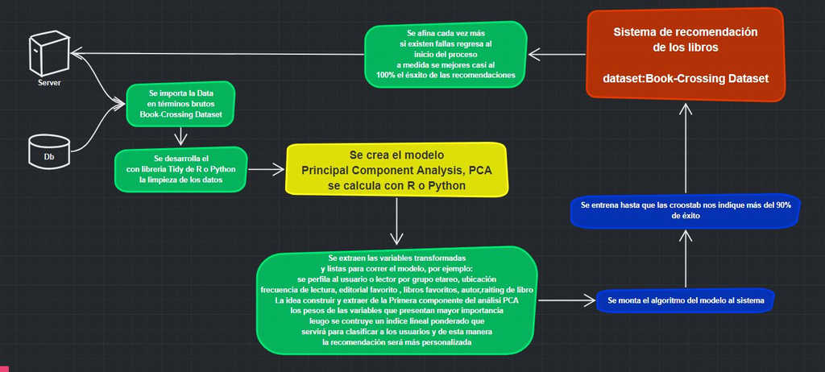

# PARTE 2: Construcción de un Modelo Machine Learning

Be-A-Host.com es un Marketplace bilateral que permite crear conexiones entre huéspedes y hospedajes. La plataforma funciona de la siguiente manera: un huésped encuentra un alojamiento disponible (listing) que le gusta y envía una solicitud al dueño del alojamiento. Hay dos formas de solicitar alojamiento, una es la de ‘reserva’ (‘book_it’) y otra la de ‘reserva instantanea’ (instant_book) que automáticamente hace la reservación. Al recibir la solicitud de ‘reserva’ el alojamiento puede decidir si aceptar o no la reservación.

Los alojamientos pueden rechazar un huésped por variar razones. Algunas pueden ser logísticas: las fechas no funcionan o personales: los huéspedes pueden ser riesgosos para el alojamiento. El objetivo de esta prueba es maximizar la probabilidad de los huéspedes de ser aceptados en el alojamiento que solicitan.

## Preguntas

Con los archivos adjuntos en el correo que recibió responda las siguientes preguntas:

1-Be-A-Host necesita comprender por qué razón un huésped logra tener una solicitud de reserva exitosa y cuales son los factores que hacen que un huésped tenga mayores probabilidades de ser aceptado por los alojamientos. Construye un modelo que permita comprender la tasa de aceptación de solicitudes. Basado en este modelo, ¿qué adición podrías recomendar hacer al website para aumentar la probabilidad de aceptación de los huéspedes?.  
2-Como un experimento Be-A-Host ha agregado un nuevo feature que obliga a los huéspedes a enviar un mensaje de no menos de 140 caracteres explicando por qué les interesa ese alojamiento en particular, las asignaciones están en el archivo assignments.csv, se corrió un experimento en que la mitad de los huéspedes se pusieron en un control. ¿Debería lanzarse ese cambio a la plataforma para todos los clientes?

## Desarrollo del Modelo

### Preparación de Librerias

```r
library(ggplot2)
library(lubridate)
library(cluster)
library(mclust)
library(pheatmap)
library(clustertend)
library(eclust)
library(NbClust)
library(pheatmap)
library(d3heatmap)
library(rattle)
library(factoextra)
library(dendextend)
library(igraph)
library(clValid)
library(nortest)
library(magrittr)
library(ggpubr)
```

### Preparación de Base de Datos

#### Base Contacts

```r
#--contacts
Contacts<- read_delim("contacts.csv", ",",
                      escape_double = FALSE, trim_ws = TRUE)

dplyr::glimpse(Contacts)
```

```
Rows: 23,143
Columns: 18
$ id_guest_anon                        <chr> "56d70d7c-1d0a-4594-a250-ed62f7cf7ac4", "dcfb93c4-07ca-41e8-b134-89b4...
$ id_host_anon                         <chr> "65a56b50-faf2-44a2-845f-0c467f41d720", "65a56b50-faf2-44a2-845f-0c46...
$ id_listing_anon                      <chr> "4deeb033-183e-437c-b94c-851ffee8cec8", "4deeb033-183e-437c-b94c-851f...
$ ts_interaction_first                 <dttm> 2013-01-13 21:03:07, 2013-01-15 23:43:49, 2013-03-19 21:30:13, 2013-...
$ ts_reply_at_first                    <dttm> 2013-01-14 21:19:42, 2013-01-16 09:04:37, 2013-03-20 12:50:49, 2013-...
$ ts_accepted_at_first                 <dttm> 2013-01-14 21:19:42, 2013-01-16 09:04:37, 2013-03-20 12:50:49, 2013-...
$ ts_booking_at                        <dttm> 2013-01-14 21:19:42, 2013-01-16 09:04:37, 2013-03-20 12:50:49, 2013-...
$ ds_checkin_first                     <date> 2013-01-18, 2013-01-23, 2013-05-31, 2013-02-09, 2013-06-06, 2013-02-...
$ ds_checkout_first                    <date> 2013-01-20, 2013-01-25, 2013-06-03, 2013-02-11, 2013-06-08, 2013-02-...
$ m_guests_first                       <dbl> 2, 2, 2, 2, 2, 2, 1, 2, 2, 2, 2, 2, 1, 2, 1, 1, 2, 1, 1, 2, 1, 2, 2, ...
$ m_interactions                       <dbl> 13, 5, 7, 5, 7, 9, 3, 4, 3, 4, 2, 9, 17, 11, 9, 4, 8, 6, 7, 9, 2, 5, ...
$ m_first_message_length_in_characters <dbl> 165, NA, 350, 426, 239, NA, 640, 487, 246, 528, 194, 279, 313, 992, 1...
$ dim_contact_channel_first            <chr> "book_it", "book_it", "book_it", "book_it", "book_it", "book_it", "bo...
$ dim_room_type                        <chr> "Private room", "Private room", "Private room", "Private room", "Priv...
$ dim_total_reviews                    <dbl> 78, 78, 78, 78, 78, 78, 78, 78, 78, 78, 78, 78, 78, 78, 78, 78, 78, 7...
$ dim_person_capacity                  <dbl> 2, 2, 2, 2, 2, 2, 2, 2, 2, 2, 2, 2, 2, 2, 2, 2, 2, 2, 2, 2, 2, 2, 2, ...
$ dim_guest_language                   <lgl> NA, NA, NA, NA, NA, NA, NA, NA, NA, NA, NA, NA, NA, NA, NA, NA, NA, N...
$ dim_host_language                    <chr> "es", "es", "es", "es", "es", "es", "es", "es", "es", "es", "es", "es...
```

```r
head(Contacts,10)
```

| id_guest_anon | id_host_anon | id_listing_anon | ts_interaction_first | ts_reply_at_first | ts_accepted_at_first | ts_booking_at | ds_checkin_first | ds_checkout_first | m_guests_first | m_interactions | m_first_message_length_in_characters | dim_contact_channel_first | dim_room_type | dim_total_reviews | dim_person_capacity | dim_guest_language | dim_host_language |
| --- | --- | --- | --- | --- | --- | --- | --- | --- | --- | --- | --- | --- | --- | --- | --- | --- | --- |
| 56d70d7c-1d0a-4594-a250-ed62f7cf7ac4 | 65a56b50-faf2-44a2-845f-0c467f41d720 | 4deeb033-183e-437c-b94c-851ffee8cec8 | 2013-01-13 21:03:07 | 2013-01-14 21:19:42 | 2013-01-14 21:19:42 | 2013-01-14 21:19:42 | 2013-01-18 | 2013-01-20 | 2 | 13 | 165 | book_it | Private room | 78 | 2 | NA | es |
| dcfb93c4-07ca-41e8-b134-89b49ddc7a36 | 65a56b50-faf2-44a2-845f-0c467f41d720 | 4deeb033-183e-437c-b94c-851ffee8cec8 | 2013-01-15 23:43:49 | 2013-01-16 09:04:37 | 2013-01-16 09:04:37 | 2013-01-16 09:04:37 | 2013-01-23 | 2013-01-25 | 2 | 5 | NA | book_it | Private room | 78 | 2 | NA | es |
| aef63ee0-7fd8-449f-867d-e710c39694e1 | 65a56b50-faf2-44a2-845f-0c467f41d720 | 4deeb033-183e-437c-b94c-851ffee8cec8 | 2013-03-19 21:30:13 | 2013-03-20 12:50:49 | 2013-03-20 12:50:49 | 2013-03-20 12:50:49 | 2013-05-31 | 2013-06-03 | 2 | 7 | 350 | book_it | Private room | 78 | 2 | NA | es |
| 58788b6f-1215-40a5-8fb0-75d2e399880c | 65a56b50-faf2-44a2-845f-0c467f41d720 | 4deeb033-183e-437c-b94c-851ffee8cec8 | 2013-01-03 16:32:01 | 2013-01-03 17:02:13 | 2013-01-03 17:02:53 | 2013-01-03 17:02:53 | 2013-02-09 | 2013-02-11 | 2 | 5 | 426 | book_it | Private room | 78 | 2 | NA | es |
| c3945c48-53b6-4e19-8bda-7d5b51d14ec1 | 65a56b50-faf2-44a2-845f-0c467f41d720 | 4deeb033-183e-437c-b94c-851ffee8cec8 | 2013-04-13 04:31:33 | 2013-04-13 16:43:53 | 2013-04-13 16:44:20 | 2013-04-13 16:44:20 | 2013-06-06 | 2013-06-08 | 2 | 7 | 239 | book_it | Private room | 78 | 2 | NA | es |
| 5dd9d290-9c2a-457e-9acb-7b6d9fc13b99 | 65a56b50-faf2-44a2-845f-0c467f41d720 | 4deeb033-183e-437c-b94c-851ffee8cec8 | 2013-02-07 17:13:18 | 2013-02-08 15:28:36 | 2013-02-08 15:58:02 | 2013-02-08 15:58:02 | 2013-02-11 | 2013-02-13 | 2 | 9 | NA | book_it | Private room | 78 | 2 | NA | es |
| e0a44946-35a7-4a0c-a5f6-b6100c85f274 | 65a56b50-faf2-44a2-845f-0c467f41d720 | 4deeb033-183e-437c-b94c-851ffee8cec8 | 2013-12-25 07:14:56 | 2013-12-26 08:20:49 |  |  | 2014-01-06 | 2014-01-11 | 1 | 3 | 640 | book_it | Private room | 78 | 2 | NA | es |
| 6602fc3b-0249-4ae2-be04-7154c2859ce1 | 65a56b50-faf2-44a2-845f-0c467f41d720 | 4deeb033-183e-437c-b94c-851ffee8cec8 | 2013-01-25 20:34:51 | 2013-01-26 15:32:58 | 2013-01-26 15:32:58 | 2013-01-26 15:32:58 | 2013-05-10 | 2013-05-13 | 2 | 4 | 487 | book_it | Private room | 78 | 2 | NA | es |
| 82b913a1-a819-4b7b-b84c-f7fe6c223f0d | 65a56b50-faf2-44a2-845f-0c467f41d720 | 4deeb033-183e-437c-b94c-851ffee8cec8 | 2013-02-10 16:52:51 | 2013-02-10 17:36:30 | 2013-02-10 17:37:30 | 2013-02-10 17:37:30 | 2013-05-17 | 2013-05-22 | 2 | 3 | 246 | book_it | Private room | 78 | 2 | NA | es |
| 6e8a1693-593c-48f5-940b-f5fabb612891 | 65a56b50-faf2-44a2-845f-0c467f41d720 | 4deeb033-183e-437c-b94c-851ffee8cec8 | 2013-01-24 17:16:28 | 2013-01-24 17:28:02 | 2013-01-24 17:28:49 | 2013-01-24 17:28:49 | 2013-06-25 | 2013-06-29 | 2 | 4 | 528 | book_it | Private room | 78 | 2 | NA | es |

#### Base Assigments

```r
#--assignments

assignments<- read_delim("assignments.csv", ",",
                      escape_double = FALSE, trim_ws = TRUE)

dplyr::glimpse(assignments)
```

```
Rows: 19,996
Columns: 2
$ id_user_anon <chr> "3e3b1bc7-9c46-4798-b955-8ed3f6bdf841", "99fef26b-5b8c-4d96-b6f4-552a951512d6", "25886018-ed8...
$ ab           <chr> "treatment", "treatment", "control", "treatment", "treatment", "treatment", "treatment", "tre...
```

```r
head(assignments,5)
```

| id_user_anon | ab |
| --- | --- |
| 3e3b1bc7-9c46-4798-b955-8ed3f6bdf841 | treatment |
| 99fef26b-5b8c-4d96-b6f4-552a951512d6 | treatment |
| 25886018-ed8c-4c40-9915-ead001e2c021 | control |
| f7e16080-c7ae-4e46-8247-26f92d4495a6 | treatment |
| 9c2d741a-acfe-4728-ba3b-0571bfd82306 | treatment |

### Fusión de bases

Se desarrolla la fusión de la base de **contacts y assigments** para empezar a prepararla y transformarla con todas sus variables, con la finalidad de empezar a desarrollar el modelo posteriormente a su transformación, además se debe saber las caracteristicas del grupo de control.

```r
#---Se fusionan las bases para el análisis para conocer el grupo de control

DB_Modelo<-left_join(Contacts,assignments,by=c("id_guest_anon"="id_user_anon"))

head(DB_Modelo,5)
```

| id_guest_anon | id_host_anon | id_listing_anon | ts_interaction_first | ts_reply_at_first | ts_accepted_at_first | ts_booking_at | ds_checkin_first | ds_checkout_first | m_guests_first | m_interactions | m_first_message_length_in_characters | dim_contact_channel_first | dim_room_type | dim_total_reviews | dim_person_capacity | dim_guest_language | dim_host_language | ab |
| --- | --- | --- | --- | --- | --- | --- | --- | --- | --- | --- | --- | --- | --- | --- | --- | --- | --- | --- |
| 56d70d7c-1d0a-4594-a250-ed62f7cf7ac4 | 65a56b50-faf2-44a2-845f-0c467f41d720 | 4deeb033-183e-437c-b94c-851ffee8cec8 | 2013-01-13 21:03:07 | 2013-01-14 21:19:42 | 2013-01-14 21:19:42 | 2013-01-14 21:19:42 | 2013-01-18 | 2013-01-20 | 2 | 13 | 165 | book_it | Private room | 78 | 2 | NA | es | control |
| dcfb93c4-07ca-41e8-b134-89b49ddc7a36 | 65a56b50-faf2-44a2-845f-0c467f41d720 | 4deeb033-183e-437c-b94c-851ffee8cec8 | 2013-01-15 23:43:49 | 2013-01-16 09:04:37 | 2013-01-16 09:04:37 | 2013-01-16 09:04:37 | 2013-01-23 | 2013-01-25 | 2 | 5 | NA | book_it | Private room | 78 | 2 | NA | es | control |
| aef63ee0-7fd8-449f-867d-e710c39694e1 | 65a56b50-faf2-44a2-845f-0c467f41d720 | 4deeb033-183e-437c-b94c-851ffee8cec8 | 2013-03-19 21:30:13 | 2013-03-20 12:50:49 | 2013-03-20 12:50:49 | 2013-03-20 12:50:49 | 2013-05-31 | 2013-06-03 | 2 | 7 | 350 | book_it | Private room | 78 | 2 | NA | es | treatment |
| 58788b6f-1215-40a5-8fb0-75d2e399880c | 65a56b50-faf2-44a2-845f-0c467f41d720 | 4deeb033-183e-437c-b94c-851ffee8cec8 | 2013-01-03 16:32:01 | 2013-01-03 17:02:13 | 2013-01-03 17:02:53 | 2013-01-03 17:02:53 | 2013-02-09 | 2013-02-11 | 2 | 5 | 426 | book_it | Private room | 78 | 2 | NA | es | treatment |
| c3945c48-53b6-4e19-8bda-7d5b51d14ec1 | 65a56b50-faf2-44a2-845f-0c467f41d720 | 4deeb033-183e-437c-b94c-851ffee8cec8 | 2013-04-13 04:31:33 | 2013-04-13 16:43:53 | 2013-04-13 16:44:20 | 2013-04-13 16:44:20 | 2013-06-06 | 2013-06-08 | 2 | 7 | 239 | book_it | Private room | 78 | 2 | NA | es | treatment |

```r
NA
```

### Preparación y Transformación de la base

Para aplicar el modelo, la base de datos deben de cumplir con un estandard de limpieza y transformación, como el modelo que se pretende aplicar es el de Clúster Jerárquico, la base debe de ser transformados a terminos númericos.

#### Se ejecuta un sub-set

```r
#----Se realiza un sut set para ir determinando la base

DB_Modelo_sub<-DB_Modelo%>%
  dplyr::select(id_guest_anon,ts_interaction_first,ts_accepted_at_first,ds_checkin_first,
                ds_checkout_first,m_guests_first,m_interactions,
                m_first_message_length_in_characters,dim_contact_channel_first,dim_room_type,
                dim_total_reviews,dim_person_capacity,ab)

dplyr::glimpse(DB_Modelo_sub)
```

```
Rows: 25,522
Columns: 13
$ id_guest_anon                        <chr> "56d70d7c-1d0a-4594-a250-ed62f7cf7ac4", "dcfb93c4-07ca-41e8-b134-89b4...
$ ts_interaction_first                 <dttm> 2013-01-13 21:03:07, 2013-01-15 23:43:49, 2013-03-19 21:30:13, 2013-...
$ ts_accepted_at_first                 <dttm> 2013-01-14 21:19:42, 2013-01-16 09:04:37, 2013-03-20 12:50:49, 2013-...
$ ds_checkin_first                     <date> 2013-01-18, 2013-01-23, 2013-05-31, 2013-02-09, 2013-06-06, 2013-02-...
$ ds_checkout_first                    <date> 2013-01-20, 2013-01-25, 2013-06-03, 2013-02-11, 2013-06-08, 2013-02-...
$ m_guests_first                       <dbl> 2, 2, 2, 2, 2, 2, 1, 2, 2, 2, 2, 2, 2, 2, 1, 2, 2, 1, 1, 1, 2, 1, 1, ...
$ m_interactions                       <dbl> 13, 5, 7, 5, 7, 9, 3, 4, 3, 4, 4, 2, 9, 9, 17, 11, 11, 9, 9, 4, 8, 6,...
$ m_first_message_length_in_characters <dbl> 165, NA, 350, 426, 239, NA, 640, 487, 246, 528, 528, 194, 279, 279, 3...
$ dim_contact_channel_first            <chr> "book_it", "book_it", "book_it", "book_it", "book_it", "book_it", "bo...
$ dim_room_type                        <chr> "Private room", "Private room", "Private room", "Private room", "Priv...
$ dim_total_reviews                    <dbl> 78, 78, 78, 78, 78, 78, 78, 78, 78, 78, 78, 78, 78, 78, 78, 78, 78, 7...
$ dim_person_capacity                  <dbl> 2, 2, 2, 2, 2, 2, 2, 2, 2, 2, 2, 2, 2, 2, 2, 2, 2, 2, 2, 2, 2, 2, 2, ...
$ ab                                   <chr> "control", "control", "treatment", "treatment", "treatment", "treatme...
```

```r
head(DB_Modelo_sub,5)
```

| id_guest_anon | ts_interaction_first | ts_accepted_at_first | ds_checkin_first | ds_checkout_first | m_guests_first | m_interactions | m_first_message_length_in_characters | dim_contact_channel_first | dim_room_type | dim_total_reviews | dim_person_capacity | ab |
| --- | --- | --- | --- | --- | --- | --- | --- | --- | --- | --- | --- | --- |
| 56d70d7c-1d0a-4594-a250-ed62f7cf7ac4 | 2013-01-13 21:03:07 | 2013-01-14 21:19:42 | 2013-01-18 | 2013-01-20 | 2 | 13 | 165 | book_it | Private room | 78 | 2 | control |
| dcfb93c4-07ca-41e8-b134-89b49ddc7a36 | 2013-01-15 23:43:49 | 2013-01-16 09:04:37 | 2013-01-23 | 2013-01-25 | 2 | 5 | NA | book_it | Private room | 78 | 2 | control |
| aef63ee0-7fd8-449f-867d-e710c39694e1 | 2013-03-19 21:30:13 | 2013-03-20 12:50:49 | 2013-05-31 | 2013-06-03 | 2 | 7 | 350 | book_it | Private room | 78 | 2 | treatment |
| 58788b6f-1215-40a5-8fb0-75d2e399880c | 2013-01-03 16:32:01 | 2013-01-03 17:02:53 | 2013-02-09 | 2013-02-11 | 2 | 5 | 426 | book_it | Private room | 78 | 2 | treatment |
| c3945c48-53b6-4e19-8bda-7d5b51d14ec1 | 2013-04-13 04:31:33 | 2013-04-13 16:44:20 | 2013-06-06 | 2013-06-08 | 2 | 7 | 239 | book_it | Private room | 78 | 2 | treatment |

```r
NA
```

#### Se ejecutan las transformaciones y recodificaciones

```r
#---Transformaciones de variables

#---Renombrando
DB_Modelo_sub<-DB_Modelo_sub%>%
  dplyr::rename(IdUser=id_guest_anon,PrimeraConsulta=ts_interaction_first,AceptaConsulta=ts_accepted_at_first,SelloEntrada=ds_checkin_first,
                SelloSalida=ds_checkout_first,NumeroInvitados=m_guests_first,NumeroMensajes=m_interactions,
                NumeroCaracteres=m_first_message_length_in_characters,TipoCanal=dim_contact_channel_first,TipoHabitacion=dim_room_type,
                TotalRevisiones=dim_total_reviews,CapacidadPersonas=dim_person_capacity,Control=ab)

dplyr::glimpse(DB_Modelo_sub)
```

```
Rows: 25,522
Columns: 13
$ IdUser            <chr> "56d70d7c-1d0a-4594-a250-ed62f7cf7ac4", "dcfb93c4-07ca-41e8-b134-89b49ddc7a36", "aef63ee...
$ PrimeraConsulta   <dttm> 2013-01-13 21:03:07, 2013-01-15 23:43:49, 2013-03-19 21:30:13, 2013-01-03 16:32:01, 201...
$ AceptaConsulta    <dttm> 2013-01-14 21:19:42, 2013-01-16 09:04:37, 2013-03-20 12:50:49, 2013-01-03 17:02:53, 201...
$ SelloEntrada      <date> 2013-01-18, 2013-01-23, 2013-05-31, 2013-02-09, 2013-06-06, 2013-02-11, 2014-01-06, 201...
$ SelloSalida       <date> 2013-01-20, 2013-01-25, 2013-06-03, 2013-02-11, 2013-06-08, 2013-02-13, 2014-01-11, 201...
$ NumeroInvitados   <dbl> 2, 2, 2, 2, 2, 2, 1, 2, 2, 2, 2, 2, 2, 2, 1, 2, 2, 1, 1, 1, 2, 1, 1, 1, 2, 1, 2, 2, 2, 1...
$ NumeroMensajes    <dbl> 13, 5, 7, 5, 7, 9, 3, 4, 3, 4, 4, 2, 9, 9, 17, 11, 11, 9, 9, 4, 8, 6, 7, 7, 9, 2, 5, 5, ...
$ NumeroCaracteres  <dbl> 165, NA, 350, 426, 239, NA, 640, 487, 246, 528, 528, 194, 279, 279, 313, 992, 992, 174, ...
$ TipoCanal         <chr> "book_it", "book_it", "book_it", "book_it", "book_it", "book_it", "book_it", "book_it", ...
$ TipoHabitacion    <chr> "Private room", "Private room", "Private room", "Private room", "Private room", "Private...
$ TotalRevisiones   <dbl> 78, 78, 78, 78, 78, 78, 78, 78, 78, 78, 78, 78, 78, 78, 78, 78, 78, 78, 78, 78, 78, 78, ...
$ CapacidadPersonas <dbl> 2, 2, 2, 2, 2, 2, 2, 2, 2, 2, 2, 2, 2, 2, 2, 2, 2, 2, 2, 2, 2, 2, 2, 2, 2, 2, 2, 2, 2, 2...
$ Control           <chr> "control", "control", "treatment", "treatment", "treatment", "treatment", "treatment", "...
```

```r
#-------Transformando

#---Verificando algunas frecuencias para las transformaciones
frq(DB_Modelo_sub$TipoHabitacion)
```

```
x <character>
# total N=25522  valid N=25522  mean=1.34  sd=0.50

Value           |     N | Raw % | Valid % | Cum. %
--------------------------------------------------
Entire home/apt | 17187 | 67.34 |   67.34 |  67.34
Private room    |  7980 | 31.27 |   31.27 |  98.61
Shared room     |   355 |  1.39 |    1.39 | 100.00
<NA>            |     0 |  0.00 |    <NA> |   <NA>
```

```r
frq(DB_Modelo_sub$TipoCanal)
```

```
x <character>
# total N=25522  valid N=25522  mean=1.14  sd=0.35

Value          |     N | Raw % | Valid % | Cum. %
-------------------------------------------------
book_it        | 21909 | 85.84 |   85.84 |  85.84
instant_booked |  3613 | 14.16 |   14.16 | 100.00
<NA>           |     0 |  0.00 |    <NA> |   <NA>
```

```r
frq(DB_Modelo_sub$Control)
```

```
x <character>
# total N=25522  valid N=25522  mean=1.50  sd=0.50

Value     |     N | Raw % | Valid % | Cum. %
--------------------------------------------
control   | 12771 | 50.04 |   50.04 |  50.04
treatment | 12751 | 49.96 |   49.96 | 100.00
<NA>      |     0 |  0.00 |    <NA> |   <NA>
```

```r
#---Tranasformaciones
DB_Transform<-DB_Modelo_sub%>%
  dplyr::mutate(TiempoEspera=(as.numeric(difftime(AceptaConsulta, PrimeraConsulta), units="secs")))%>%
  dplyr::mutate(TiempoSello=(as.numeric(difftime(SelloSalida, SelloEntrada), units="days")))%>%
  dplyr::mutate(Canal=(if_else(TipoCanal=="instant_booked",1,2))) %>%
  dplyr::mutate(Habitacion=(if_else(TipoHabitacion=="Entire home/apt",1,
                                    if_else(TipoHabitacion=="Private room",2,if_else(TipoHabitacion=="Shared room",3,4 ))))) %>%
  dplyr::mutate(GrupoControl=if_else(Control=="control",1, 2),corr=seq(1,25522,by=1))

head(DB_Transform,5)
```

| IdUser | PrimeraConsulta | AceptaConsulta | SelloEntrada | SelloSalida | NumeroInvitados | NumeroMensajes | NumeroCaracteres | TipoCanal | TipoHabitacion | TotalRevisiones | CapacidadPersonas | Control | TiempoEspera | TiempoSello | Canal | Habitacion | GrupoControl | corr |
| --- | --- | --- | --- | --- | --- | --- | --- | --- | --- | --- | --- | --- | --- | --- | --- | --- | --- | --- |
| 56d70d7c-1d0a-4594-a250-ed62f7cf7ac4 | 2013-01-13 21:03:07 | 2013-01-14 21:19:42 | 2013-01-18 | 2013-01-20 | 2 | 13 | 165 | book_it | Private room | 78 | 2 | control | 87395 | 2 | 2 | 2 | 1 | 1 |
| dcfb93c4-07ca-41e8-b134-89b49ddc7a36 | 2013-01-15 23:43:49 | 2013-01-16 09:04:37 | 2013-01-23 | 2013-01-25 | 2 | 5 | NA | book_it | Private room | 78 | 2 | control | 33648 | 2 | 2 | 2 | 1 | 2 |
| aef63ee0-7fd8-449f-867d-e710c39694e1 | 2013-03-19 21:30:13 | 2013-03-20 12:50:49 | 2013-05-31 | 2013-06-03 | 2 | 7 | 350 | book_it | Private room | 78 | 2 | treatment | 55236 | 3 | 2 | 2 | 2 | 3 |
| 58788b6f-1215-40a5-8fb0-75d2e399880c | 2013-01-03 16:32:01 | 2013-01-03 17:02:53 | 2013-02-09 | 2013-02-11 | 2 | 5 | 426 | book_it | Private room | 78 | 2 | treatment | 1852 | 2 | 2 | 2 | 2 | 4 |
| c3945c48-53b6-4e19-8bda-7d5b51d14ec1 | 2013-04-13 04:31:33 | 2013-04-13 16:44:20 | 2013-06-06 | 2013-06-08 | 2 | 7 | 239 | book_it | Private room | 78 | 2 | treatment | 43967 | 2 | 2 | 2 | 2 | 5 |

### Seleccionando las variables que entraran al modelo

```r
#---Seleccionando las variables que entraran al modelo
dplyr::glimpse(DB_Transform)
```

```
Rows: 25,522
Columns: 19
$ IdUser            <chr> "56d70d7c-1d0a-4594-a250-ed62f7cf7ac4", "dcfb93c4-07ca-41e8-b134-89b49ddc7a36", "aef63ee...
$ PrimeraConsulta   <dttm> 2013-01-13 21:03:07, 2013-01-15 23:43:49, 2013-03-19 21:30:13, 2013-01-03 16:32:01, 201...
$ AceptaConsulta    <dttm> 2013-01-14 21:19:42, 2013-01-16 09:04:37, 2013-03-20 12:50:49, 2013-01-03 17:02:53, 201...
$ SelloEntrada      <date> 2013-01-18, 2013-01-23, 2013-05-31, 2013-02-09, 2013-06-06, 2013-02-11, 2014-01-06, 201...
$ SelloSalida       <date> 2013-01-20, 2013-01-25, 2013-06-03, 2013-02-11, 2013-06-08, 2013-02-13, 2014-01-11, 201...
$ NumeroInvitados   <dbl> 2, 2, 2, 2, 2, 2, 1, 2, 2, 2, 2, 2, 2, 2, 1, 2, 2, 1, 1, 1, 2, 1, 1, 1, 2, 1, 2, 2, 2, 1...
$ NumeroMensajes    <dbl> 13, 5, 7, 5, 7, 9, 3, 4, 3, 4, 4, 2, 9, 9, 17, 11, 11, 9, 9, 4, 8, 6, 7, 7, 9, 2, 5, 5, ...
$ NumeroCaracteres  <dbl> 165, NA, 350, 426, 239, NA, 640, 487, 246, 528, 528, 194, 279, 279, 313, 992, 992, 174, ...
$ TipoCanal         <chr> "book_it", "book_it", "book_it", "book_it", "book_it", "book_it", "book_it", "book_it", ...
$ TipoHabitacion    <chr> "Private room", "Private room", "Private room", "Private room", "Private room", "Private...
$ TotalRevisiones   <dbl> 78, 78, 78, 78, 78, 78, 78, 78, 78, 78, 78, 78, 78, 78, 78, 78, 78, 78, 78, 78, 78, 78, ...
$ CapacidadPersonas <dbl> 2, 2, 2, 2, 2, 2, 2, 2, 2, 2, 2, 2, 2, 2, 2, 2, 2, 2, 2, 2, 2, 2, 2, 2, 2, 2, 2, 2, 2, 2...
$ Control           <chr> "control", "control", "treatment", "treatment", "treatment", "treatment", "treatment", "...
$ TiempoEspera      <dbl> 87395, 33648, 55236, 1852, 43967, 81884, NA, 68287, 2679, 741, 741, 49878, 13617, 13617,...
$ TiempoSello       <dbl> 2, 2, 3, 2, 2, 2, 5, 3, 5, 4, 4, 5, 3, 3, 2, 4, 4, 3, 3, 1, 2, 4, 1, 1, 1, 12, 1, 2, 2, ...
$ Canal             <dbl> 2, 2, 2, 2, 2, 2, 2, 2, 2, 2, 2, 2, 2, 2, 2, 2, 2, 2, 2, 2, 2, 2, 2, 2, 2, 2, 2, 2, 2, 2...
$ Habitacion        <dbl> 2, 2, 2, 2, 2, 2, 2, 2, 2, 2, 2, 2, 2, 2, 2, 2, 2, 2, 2, 2, 2, 2, 2, 2, 2, 2, 2, 2, 2, 2...
$ GrupoControl      <dbl> 1, 1, 2, 2, 2, 2, 2, 2, 2, 2, 1, 1, 1, 1, 2, 2, 2, 2, 1, 1, 1, 1, 1, 1, 1, 2, 1, 1, 1, 1...
$ corr              <dbl> 1, 2, 3, 4, 5, 6, 7, 8, 9, 10, 11, 12, 13, 14, 15, 16, 17, 18, 19, 20, 21, 22, 23, 24, 2...
```

```r
bm<-DB_Transform %>%
  dplyr::select(TiempoEspera,TiempoSello,NumeroInvitados,NumeroMensajes,NumeroCaracteres,Canal,Habitacion,
                TotalRevisiones,CapacidadPersonas,corr)

dplyr::glimpse(bm)
```

```
Rows: 25,522
Columns: 10
$ TiempoEspera      <dbl> 87395, 33648, 55236, 1852, 43967, 81884, NA, 68287, 2679, 741, 741, 49878, 13617, 13617,...
$ TiempoSello       <dbl> 2, 2, 3, 2, 2, 2, 5, 3, 5, 4, 4, 5, 3, 3, 2, 4, 4, 3, 3, 1, 2, 4, 1, 1, 1, 12, 1, 2, 2, ...
$ NumeroInvitados   <dbl> 2, 2, 2, 2, 2, 2, 1, 2, 2, 2, 2, 2, 2, 2, 1, 2, 2, 1, 1, 1, 2, 1, 1, 1, 2, 1, 2, 2, 2, 1...
$ NumeroMensajes    <dbl> 13, 5, 7, 5, 7, 9, 3, 4, 3, 4, 4, 2, 9, 9, 17, 11, 11, 9, 9, 4, 8, 6, 7, 7, 9, 2, 5, 5, ...
$ NumeroCaracteres  <dbl> 165, NA, 350, 426, 239, NA, 640, 487, 246, 528, 528, 194, 279, 279, 313, 992, 992, 174, ...
$ Canal             <dbl> 2, 2, 2, 2, 2, 2, 2, 2, 2, 2, 2, 2, 2, 2, 2, 2, 2, 2, 2, 2, 2, 2, 2, 2, 2, 2, 2, 2, 2, 2...
$ Habitacion        <dbl> 2, 2, 2, 2, 2, 2, 2, 2, 2, 2, 2, 2, 2, 2, 2, 2, 2, 2, 2, 2, 2, 2, 2, 2, 2, 2, 2, 2, 2, 2...
$ TotalRevisiones   <dbl> 78, 78, 78, 78, 78, 78, 78, 78, 78, 78, 78, 78, 78, 78, 78, 78, 78, 78, 78, 78, 78, 78, ...
$ CapacidadPersonas <dbl> 2, 2, 2, 2, 2, 2, 2, 2, 2, 2, 2, 2, 2, 2, 2, 2, 2, 2, 2, 2, 2, 2, 2, 2, 2, 2, 2, 2, 2, 2...
$ corr              <dbl> 1, 2, 3, 4, 5, 6, 7, 8, 9, 10, 11, 12, 13, 14, 15, 16, 17, 18, 19, 20, 21, 22, 23, 24, 2...
```

```r
head(bm,5)
```

| TiempoEspera | TiempoSello | NumeroInvitados | NumeroMensajes | NumeroCaracteres | Canal | Habitacion | TotalRevisiones | CapacidadPersonas | corr |
| --- | --- | --- | --- | --- | --- | --- | --- | --- | --- |
| 87395 | 2 | 2 | 13 | 165 | 2 | 2 | 78 | 2 | 1 |
| 33648 | 2 | 2 | 5 | NA | 2 | 2 | 78 | 2 | 2 |
| 55236 | 3 | 2 | 7 | 350 | 2 | 2 | 78 | 2 | 3 |
| 1852 | 2 | 2 | 5 | 426 | 2 | 2 | 78 | 2 | 4 |
| 43967 | 2 | 2 | 7 | 239 | 2 | 2 | 78 | 2 | 5 |

### Se calcula una muestra representativa para correr el modelo que también será de entrenamiento

```r
#----Se sacará una muestra representativa de la base que a la vez servirá para entrenamiento
#----la muestra se reduce por la eliminación de los NA de hecho por eso se sobremuestrea a 7000

bm_muestra<-bm %>%
  sample_n(size=7000,replace=FALSE)

bm_muestra<-na.omit(bm_muestra)

bm<-bm_muestra

dplyr::glimpse(bm)
```

```
Rows: 4,554
Columns: 10
$ TiempoEspera      <dbl> 424, 46296, 0, 0, 32578, 2447, 25784, 11436, 852, 417, 13363, 28078, 1370, 48939, 15994,...
$ TiempoSello       <dbl> 5, 5, 1, 2, 4, 3, 3, 4, 2, 20, 31, 1, 4, 7, 1, 2, 3, 2, 3, 2, 5, 3, 2, 3, 7, 4, 3, 5, 3,...
$ NumeroInvitados   <dbl> 3, 1, 1, 1, 4, 2, 2, 5, 2, 1, 1, 2, 4, 1, 2, 4, 2, 2, 2, 2, 6, 4, 2, 1, 1, 1, 2, 3, 5, 3...
$ NumeroMensajes    <dbl> 9, 5, 3, 5, 5, 7, 6, 2, 6, 14, 2, 11, 13, 6, 3, 8, 9, 5, 3, 8, 9, 8, 8, 9, 8, 9, 11, 8, ...
$ NumeroCaracteres  <dbl> 165, 210, 375, 181, 398, 502, 273, 263, 231, 376, 0, 220, 693, 222, 151, 0, 564, 178, 30...
$ Canal             <dbl> 2, 2, 1, 1, 2, 2, 2, 2, 2, 2, 2, 2, 2, 2, 2, 2, 2, 2, 1, 1, 2, 2, 1, 2, 1, 2, 1, 2, 2, 2...
$ Habitacion        <dbl> 1, 2, 2, 1, 1, 1, 1, 1, 2, 1, 2, 2, 1, 2, 1, 1, 2, 2, 1, 1, 1, 1, 1, 2, 1, 2, 2, 1, 1, 1...
$ TotalRevisiones   <dbl> 96, 37, 321, 199, 17, 90, 94, 93, 20, 37, 5, 108, 20, 109, 87, 80, 7, 64, 134, 134, 44, ...
$ CapacidadPersonas <dbl> 4, 2, 3, 3, 5, 2, 4, 8, 2, 2, 2, 1, 4, 2, 10, 4, 4, 4, 2, 2, 8, 4, 4, 4, 3, 2, 2, 6, 5, ...
$ corr              <dbl> 4764, 6964, 8492, 3060, 10143, 18445, 13845, 5747, 20645, 9226, 24744, 8807, 10020, 504,...
```

```r
head(bm,5)
```

| TiempoEspera | TiempoSello | NumeroInvitados | NumeroMensajes | NumeroCaracteres | Canal | Habitacion | TotalRevisiones | CapacidadPersonas | corr |
| --- | --- | --- | --- | --- | --- | --- | --- | --- | --- |
| 424 | 5 | 3 | 9 | 165 | 2 | 1 | 96 | 4 | 4764 |
| 46296 | 5 | 1 | 5 | 210 | 2 | 2 | 37 | 2 | 6964 |
| 0 | 1 | 1 | 3 | 375 | 1 | 2 | 321 | 3 | 8492 |
| 0 | 2 | 1 | 5 | 181 | 1 | 1 | 199 | 3 | 3060 |
| 32578 | 4 | 4 | 5 | 398 | 2 | 1 | 17 | 5 | 10143 |

### Desarrollo del modelo de Clúster Jerárquico

#### Escalando la base

```r
#----Modelo de cluster jerarquico
#---Escalando la base bm (normalizando o tipificando)

bm<-scale(bm)

head(bm,5)
```

```
     TiempoEspera TiempoSello NumeroInvitados NumeroMensajes NumeroCaracteres      Canal Habitacion TotalRevisiones
[1,] -0.055571642  0.11990268       0.5145576     0.08478691       -0.5907017  0.4779503 -0.5971281       0.6598345
[2,]  0.014781812  0.11990268      -0.9798909    -0.65632558       -0.3415686  0.4779503  1.4914444      -0.5151706
[3,] -0.056221927 -0.49918669      -0.9798909    -1.02688182        0.5719191 -2.0918084  1.4914444       5.1407864
[4,] -0.056221927 -0.34441434      -0.9798909    -0.65632558       -0.5021210 -2.0918084 -0.5971281       2.7111147
[5,] -0.006257355 -0.03486966       1.2617818    -0.65632558        0.6992538  0.4779503 -0.5971281      -0.9134775
     CapacidadPersonas       corr
[1,]         0.1154639 -1.0536085
[2,]        -0.7919092 -0.7390664
[3,]        -0.3382227 -0.5206027
[4,]        -0.3382227 -1.2972356
[5,]         0.5691505 -0.2845532
```

#### Definiendo el número óptimo de clústers

Las pruebas gráficas por el método de **ELBOW y el método de AVERAGE SILHOUETTE**, indican entre 4 y 3, clúster, decidí determinarlo en 3 clústers porque la prueba de calidad del clúster, que es el próximo ítems indica mejor establecimiento para 3 grupos.

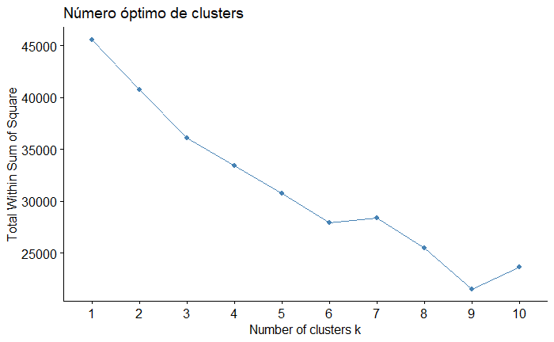

```r
#--------Número optimo de cluster---Método: ELBOW
fviz_nbclust(x = bm, FUNcluster = kmeans, method = "wss") +
  labs(title = "Número óptimo de clusters")
```

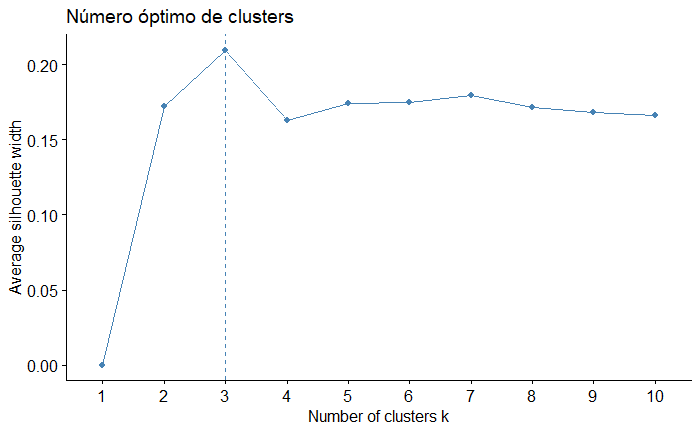

```r
#--------Número optimo de cluster---Método: AVERAGE SILHOUETTE METHOD
fviz_nbclust(x = bm, FUNcluster = kmeans, method = "silhouette") +
  labs(title = "Número óptimo de clusters")
```

#### Calidad de los grupos del cluster

Tal como se comento en la sección anterior la calidad del clúster indica mejor agrupamiento para 3 grupos.

|  | cluster | size | ave.sil.width |
| --- | --- | --- | --- |
| 1 | 1 | 843 | 0.27 |
| 2 | 2 | 2655 | 0.18 |
| 3 | 3 | 1056 | 0.23 |

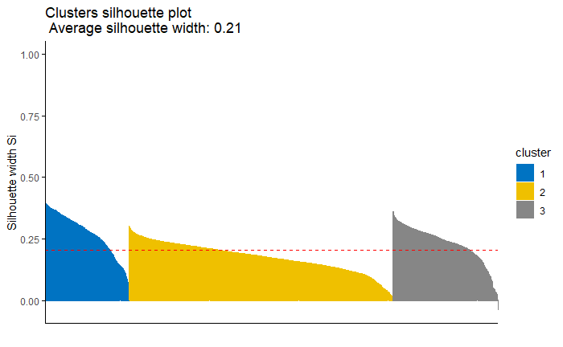

```r
#------Gráfico de Silhouette width
km_clusters <- eclust(x = bm, FUNcluster = "kmeans", k = 3, seed = 123,
                      hc_metric = "euclidean", nstart = 50, graph = FALSE)
fviz_silhouette(sil.obj = km_clusters, print.summary = TRUE, palette = "jco",
                ggtheme = theme_classic())
```

#### Visualización gráfica de los grupos

Se observa a continuación la representación gráfica de los clústers conformados:

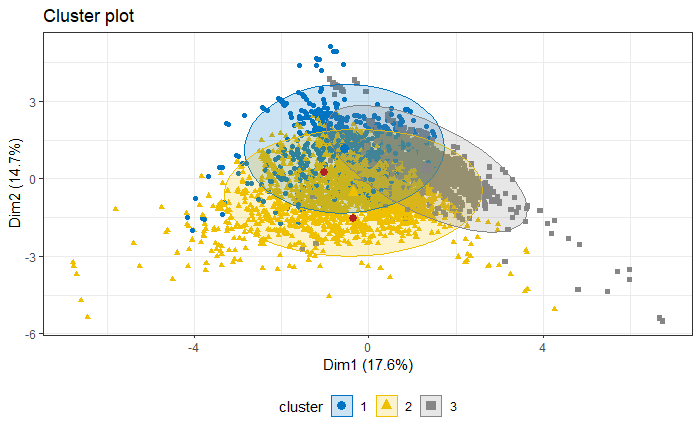

```r
#----Gráfica del cluster
p <- fviz_cluster(object = km_clusters, geom = "point", ellipse.type = "norm",
                  palette = "jco")
p + geom_point(data = p$data[c(1, 3000),], colour = "firebrick", size = 2.5) +
  theme_bw() + theme(legend.position = "bottom")
```

```r
NA
NA
```

#### Dendograma

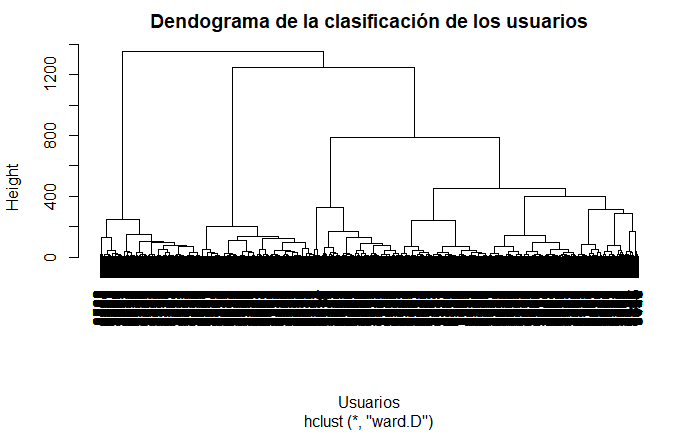

```r
#----Dendograma
hc_completo <- bm %>% scale() %>% dist(method = "euclidean") %>% hclust(method = "ward.D")

plot(hc_completo, main="Dendograma de la clasificación de los usuarios",xlab="Usuarios")
```

#### Heatmap

se construyé el heatmap:

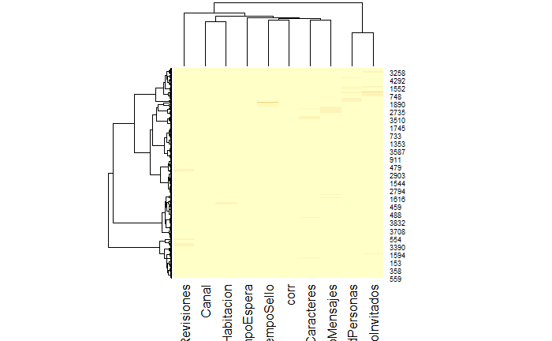

```r
#------heatmap
heatmap(x = bm, scale = "none", distfun = function(x){dist(x, method = "euclidean")},
        hclustfun = function(x){hclust(x, method = "ward.D")}, cexRow = 0.7)
```

#### Preparando la base para el análisis

En este apartado se fusionan los cluster con la base de entrenamiento o muestra para desarrollar los análisis de recomendación para la respuestas de los númerales 1 y 2

```r
#-----------Preparando la base
clusters <- cutree(tree = hc_completo, k = 3)

clusters
```

```
   [1] 1 2 3 3 1 1 1 1 2 1 1 2 1 2 1 1 2 2 3 3 1 1 3 2 3 2 3 1 1 1 3 1 2 1 1 1 1 1 1 1 1 1 3 1 1 3 3 1 1 3 1 2 1 3 1 3
  [57] 1 3 3 1 1 1 2 1 1 2 1 3 3 3 1 1 1 1 2 1 3 1 1 3 1 1 3 2 1 1 2 1 1 2 1 1 2 1 2 1 2 3 1 1 2 1 3 1 1 2 1 1 1 1 1 2
 [113] 2 1 1 3 1 1 1 1 3 1 3 1 1 1 1 1 1 1 1 1 2 1 1 1 1 2 1 3 1 1 1 1 1 1 1 3 1 2 3 3 3 1 2 3 1 1 3 1 1 1 2 1 1 3 1 1
 [169] 3 3 2 1 1 1 2 2 1 2 1 2 1 1 1 2 1 1 1 1 2 3 1 3 1 1 3 1 1 1 1 3 2 3 3 1 1 1 2 3 1 3 1 1 2 3 2 3 3 1 1 1 1 3 1 1
 [225] 3 1 1 1 2 3 1 1 2 3 1 1 2 3 2 3 1 1 1 1 1 1 2 3 3 2 1 1 3 1 2 1 3 1 1 3 3 2 1 1 3 3 3 3 1 2 1 2 1 1 1 1 1 1 1 1
 [281] 1 1 1 2 2 1 1 1 1 2 3 2 1 3 1 1 3 2 1 2 1 3 1 1 1 3 1 1 3 3 2 1 3 1 1 2 1 1 1 1 1 2 1 1 1 2 3 1 1 1 2 2 1 1 1 3
 [337] 3 3 3 2 1 1 1 1 2 1 1 1 1 1 1 2 2 1 3 1 3 3 3 2 1 1 1 1 2 1 3 1 1 1 2 2 1 1 2 3 1 1 1 2 1 1 1 3 1 2 1 2 1 1 3 1
 [393] 2 3 3 1 1 2 1 1 2 1 1 3 1 1 3 1 1 1 1 2 1 2 1 2 1 1 1 1 1 2 1 2 1 2 1 1 2 1 3 3 1 1 1 1 3 3 2 3 3 2 3 1 3 1 1 1
 [449] 1 3 1 1 2 1 1 1 2 2 2 2 1 3 1 2 1 1 1 1 1 2 2 1 2 3 2 1 3 1 1 1 3 1 2 2 1 1 3 2 1 3 1 1 1 1 3 1 1 1 2 3 1 1 3 1
 [505] 1 2 2 1 1 1 2 1 1 1 1 2 2 1 2 1 3 1 1 1 1 2 2 1 2 1 3 3 1 3 1 2 3 1 2 2 1 3 3 2 3 3 1 2 2 3 3 1 1 2 2 1 3 1 3 2
 [561] 1 1 1 1 1 3 1 1 2 1 1 1 1 1 1 1 2 2 1 2 1 2 2 1 3 1 2 3 1 1 3 1 2 3 2 1 1 1 2 3 1 1 1 1 1 1 3 1 1 1 1 1 1 2 2 1
 [617] 3 2 1 2 1 2 3 1 2 3 2 2 2 1 1 2 2 2 1 1 3 3 3 1 2 3 1 3 1 3 1 2 1 3 1 2 1 1 1 1 1 1 1 1 2 1 1 1 1 1 1 2 1 1 2 1
 [673] 3 1 1 1 2 2 2 2 3 1 1 1 1 1 2 1 1 2 3 3 1 3 1 1 1 1 1 2 3 1 1 1 1 1 1 1 3 1 1 3 1 1 1 1 1 1 1 2 1 2 1 2 3 1 3 1
 [729] 1 3 1 1 1 1 2 1 1 1 3 1 3 1 1 1 1 1 1 1 1 1 3 1 1 1 2 2 3 1 1 1 1 1 1 1 3 1 1 1 2 1 1 1 2 2 3 2 3 3 1 2 3 1 3 1
 [785] 1 2 1 2 1 1 3 1 3 3 1 2 3 1 1 1 1 1 1 3 2 1 1 2 2 1 3 1 1 2 3 1 3 2 1 1 1 1 1 1 2 3 1 1 1 2 1 1 1 2 1 3 1 3 1 3
 [841] 2 1 3 1 1 2 2 2 1 1 1 1 3 3 1 3 1 1 2 1 3 2 1 3 1 2 3 3 2 1 1 3 1 3 2 1 1 1 2 2 2 1 2 1 1 1 3 3 3 1 3 2 1 2 1 1
 [897] 1 3 2 2 3 2 1 1 1 2 2 1 2 1 1 1 3 1 1 3 3 1 1 1 1 1 1 1 1 1 1 3 3 1 2 1 1 1 3 3 2 2 1 1 2 1 3 1 1 1 1 3 1 1 1 2
 [953] 1 1 2 1 1 1 1 1 2 1 1 2 1 1 3 1 2 1 3 3 1 1 1 1 2 3 1 1 3 2 1 3 1 2 3 3 2 1 3 1 1 1 1 1 3 1 2 1
 [ reached getOption("max.print") -- omitted 3554 entries ]
```

```r
clusterBD<-cbind(clusters,bm_muestra)

#--join para agregar la columna control

SubsetBD_Transf<- DB_Transform %>%
  dplyr::select(GrupoControl,corr)


dplyr::glimpse(clusterBD)
```

```
Rows: 4,554
Columns: 11
$ clusters          <int> 1, 2, 3, 3, 1, 1, 1, 1, 2, 1, 1, 2, 1, 2, 1, 1, 2, 2, 3, 3, 1, 1, 3, 2, 3, 2, 3, 1, 1, 1...
$ TiempoEspera      <dbl> 424, 46296, 0, 0, 32578, 2447, 25784, 11436, 852, 417, 13363, 28078, 1370, 48939, 15994,...
$ TiempoSello       <dbl> 5, 5, 1, 2, 4, 3, 3, 4, 2, 20, 31, 1, 4, 7, 1, 2, 3, 2, 3, 2, 5, 3, 2, 3, 7, 4, 3, 5, 3,...
$ NumeroInvitados   <dbl> 3, 1, 1, 1, 4, 2, 2, 5, 2, 1, 1, 2, 4, 1, 2, 4, 2, 2, 2, 2, 6, 4, 2, 1, 1, 1, 2, 3, 5, 3...
$ NumeroMensajes    <dbl> 9, 5, 3, 5, 5, 7, 6, 2, 6, 14, 2, 11, 13, 6, 3, 8, 9, 5, 3, 8, 9, 8, 8, 9, 8, 9, 11, 8, ...
$ NumeroCaracteres  <dbl> 165, 210, 375, 181, 398, 502, 273, 263, 231, 376, 0, 220, 693, 222, 151, 0, 564, 178, 30...
$ Canal             <dbl> 2, 2, 1, 1, 2, 2, 2, 2, 2, 2, 2, 2, 2, 2, 2, 2, 2, 2, 1, 1, 2, 2, 1, 2, 1, 2, 1, 2, 2, 2...
$ Habitacion        <dbl> 1, 2, 2, 1, 1, 1, 1, 1, 2, 1, 2, 2, 1, 2, 1, 1, 2, 2, 1, 1, 1, 1, 1, 2, 1, 2, 2, 1, 1, 1...
$ TotalRevisiones   <dbl> 96, 37, 321, 199, 17, 90, 94, 93, 20, 37, 5, 108, 20, 109, 87, 80, 7, 64, 134, 134, 44, ...
$ CapacidadPersonas <dbl> 4, 2, 3, 3, 5, 2, 4, 8, 2, 2, 2, 1, 4, 2, 10, 4, 4, 4, 2, 2, 8, 4, 4, 4, 3, 2, 2, 6, 5, ...
$ corr              <dbl> 4764, 6964, 8492, 3060, 10143, 18445, 13845, 5747, 20645, 9226, 24744, 8807, 10020, 504,...
```

```r
dplyr::glimpse(SubsetBD_Transf)
```

```
Rows: 25,522
Columns: 2
$ GrupoControl <dbl> 1, 1, 2, 2, 2, 2, 2, 2, 2, 2, 1, 1, 1, 1, 2, 2, 2, 2, 1, 1, 1, 1, 1, 1, 1, 2, 1, 1, 1, 1, 2, ...
$ corr         <dbl> 1, 2, 3, 4, 5, 6, 7, 8, 9, 10, 11, 12, 13, 14, 15, 16, 17, 18, 19, 20, 21, 22, 23, 24, 25, 26...
```

```r
clusterBD<-left_join(clusterBD,SubsetBD_Transf,by=c("corr"="corr"))


dplyr::glimpse(clusterBD)
```

```
Rows: 4,554
Columns: 12
$ clusters          <int> 1, 2, 3, 3, 1, 1, 1, 1, 2, 1, 1, 2, 1, 2, 1, 1, 2, 2, 3, 3, 1, 1, 3, 2, 3, 2, 3, 1, 1, 1...
$ TiempoEspera      <dbl> 424, 46296, 0, 0, 32578, 2447, 25784, 11436, 852, 417, 13363, 28078, 1370, 48939, 15994,...
$ TiempoSello       <dbl> 5, 5, 1, 2, 4, 3, 3, 4, 2, 20, 31, 1, 4, 7, 1, 2, 3, 2, 3, 2, 5, 3, 2, 3, 7, 4, 3, 5, 3,...
$ NumeroInvitados   <dbl> 3, 1, 1, 1, 4, 2, 2, 5, 2, 1, 1, 2, 4, 1, 2, 4, 2, 2, 2, 2, 6, 4, 2, 1, 1, 1, 2, 3, 5, 3...
$ NumeroMensajes    <dbl> 9, 5, 3, 5, 5, 7, 6, 2, 6, 14, 2, 11, 13, 6, 3, 8, 9, 5, 3, 8, 9, 8, 8, 9, 8, 9, 11, 8, ...
$ NumeroCaracteres  <dbl> 165, 210, 375, 181, 398, 502, 273, 263, 231, 376, 0, 220, 693, 222, 151, 0, 564, 178, 30...
$ Canal             <dbl> 2, 2, 1, 1, 2, 2, 2, 2, 2, 2, 2, 2, 2, 2, 2, 2, 2, 2, 1, 1, 2, 2, 1, 2, 1, 2, 1, 2, 2, 2...
$ Habitacion        <dbl> 1, 2, 2, 1, 1, 1, 1, 1, 2, 1, 2, 2, 1, 2, 1, 1, 2, 2, 1, 1, 1, 1, 1, 2, 1, 2, 2, 1, 1, 1...
$ TotalRevisiones   <dbl> 96, 37, 321, 199, 17, 90, 94, 93, 20, 37, 5, 108, 20, 109, 87, 80, 7, 64, 134, 134, 44, ...
$ CapacidadPersonas <dbl> 4, 2, 3, 3, 5, 2, 4, 8, 2, 2, 2, 1, 4, 2, 10, 4, 4, 4, 2, 2, 8, 4, 4, 4, 3, 2, 2, 6, 5, ...
$ corr              <dbl> 4764, 6964, 8492, 3060, 10143, 18445, 13845, 5747, 20645, 9226, 24744, 8807, 10020, 504,...
$ GrupoControl      <dbl> 1, 2, 2, 2, 2, 2, 1, 2, 2, 1, 1, 2, 2, 1, 2, 1, 2, 1, 2, 1, 2, 2, 1, 1, 2, 1, 2, 1, 1, 2...
```

```r
frq(clusterBD$clusters)
```

```
x <integer>
# total N=4554  valid N=4554  mean=1.59  sd=0.79

Value |    N | Raw % | Valid % | Cum. %
---------------------------------------
    1 | 2742 | 60.21 |   60.21 |  60.21
    2 |  959 | 21.06 |   21.06 |  81.27
    3 |  853 | 18.73 |   18.73 | 100.00
 <NA> |    0 |  0.00 |    <NA> |   <NA>
```